# Quantile Regression of Rangeland Productivity - Quantile Regression Forests

Guy Lomax

2023-06-19

This Notebook conducts quantile regression on rangeland productivity data using Quantile Regression Forests (QRF), modelling annual gross primary productivity (GPP) as a function of environmental variables

# Exploratory data analysis

# Data preparation for RF modelling

We select variables to use for modelling, remove rows containing NA values (the TWI raster has some pixels with NA values) and convert to a spatiotemporal regression task. We assign point id (“id”) as our index of spatial location and “year” as our index of time.

We then choose our learner (random forest regression through the ranger package) with quantile regression enabled, and define two alternative resampling (cross- validation) strategies: random CV and “Leave-location-and-time-out” CV that ensures the validation set for each fold does not overlap in either time or space with the training set.

When defining the learner, we initially choose crude, plausible hyperparameters of mtry.ratio = 0.5 and sample.fraction = 0.5. However, we set the initial minimum node size to 200 (around 0.1% of the dataset) to mitigate overfitting and to allow sufficient terminal node size that quantiles can be calculated. For our purposes, absolute predictive accuracy is less important than retaining enough variability in nodes to allow assessment of quantiles.

```r
# Create task

cols_to_retain <- c(
  "id",
  "year",
  "GPP",
  "wriTCFrac",
  "mean_ppt",
  "ppt_anomaly",
  "meanPptDay_anomaly",
  "sdii",
  "ugi",
  "slope",
  "distToRiver",
  "landform",
  "twi",
  "tMean",
  "parMean",
  "potentialET",
  "sand"
)

sample_points_subset <- sample_points_derived %>%
  drop_na() %>%
  select(all_of(cols_to_retain))

task_gpp <- as_task_regr_st(
  x = sample_points_subset,
  id = "potential_gpp",
  target = "GPP",
  coords_as_features = FALSE,
  crs = "epsg:4326"
)

task_gpp$set_col_roles("id", roles = "space")
task_gpp$set_col_roles("year", roles = "time")

# Create learner (ranger random forest) with initial tuning values

lrn_ranger_untuned <- lrn("regr.ranger",
                          predict_type = "response",
                          num.trees = 1001,
                          mtry.ratio = 0.5,
                          min.node.size = 200,
                          sample.fraction = 0.5
)

set_threads(lrn_ranger_untuned, 1)
```

```
<LearnerRegrRanger:regr.ranger>
* Model: -
* Parameters: num.threads=1, num.trees=1001, mtry.ratio=0.5, min.node.size=200, sample.fraction=0.5
* Packages: mlr3, mlr3learners, ranger
* Predict Types:  [response], se
* Feature Types: logical, integer, numeric, character, factor, ordered
* Properties: hotstart_backward, importance, oob_error, weights
```

```r
# Create resampling strategy

spt_cv_plan <- rsmp("sptcv_cstf", folds = 10)
nspt_cv_plan <- rsmp("cv", folds = 10)
```

# Feature selection

We use forward feature selection with the untuned model to identify which covariates have unique information to predict GPP. For this, we start by building all possible single-variable models. Then, selecting the variable that gives the best performance (lowest RMSE in this case), we build all possible two-variable models that include this variable. We do the same with a third variable, and so on, until the point at which adding an additional variable fails to improve model performance.

We do this separately for models using random CV and spatio-temporal CV, and save the optimum feature set for each.

# Hyper-parameter optimisation (model tuning)

Now we have identified relevant features (and, hopefully, excluded those with minimal predictive power), we can use that feature set to tune hyperparameters for a new set of models.

We create two new tasks, each with the variables selected from the previous step. Then we define a new learner allowing for tuning of hyperparameters. Finally, we pass the learner and task to an auto-tuner object for each of the two CV methods. We use a random search to identify hyperparameters that give decent performance; we are not worried about perfection!

```r
# Spatial model

set.seed(789)

tic()
rf_tuned_spt <- progressr::with_progress(
  at_spt$train(task_gpp_spt)
)
toc(log = T)
# beep(3)

write_rds(rf_tuned_spt, here("results", "rds", "rf_tuned_spt.rds"))

# rm(rf_tuned_spt)
# gc()

# Non-spatial RF model (random CV)

set.seed(987)

tic()
rf_tuned_nspt <- progressr::with_progress(
  at_nspt$train(task_gpp_nspt)
)
toc(log = T)
# beep(3)

write_rds(rf_tuned_nspt, here("results", "rds", "rf_tuned_nspt.rds"))

rm(rf_tuned_nspt)
gc()
```

Performance assessment of spatial and non-spatial models

```r
rf_tuned_spt <- read_rds(here("results", "rds", "rf_tuned_spt.rds"))
rf_tuned_nspt <- read_rds(here("results", "rds", "rf_tuned_nspt.rds"))

# Measures to evaluate model performance
measures <- msrs(c("regr.mae", "regr.rmse", "regr.rsq"))
measures_micro <- msrs(c("regr.mae", "regr.rmse", "regr.rsq"), average = "micro")

rf_predictions_spt <- rf_tuned_spt$predict(task_gpp_spt)
rf_predictions_nspt <- rf_tuned_nspt$predict(task_gpp_nspt)

rf_predictions_spt$score(measures)
```

```
  regr.mae  regr.rmse   regr.rsq
395.981234 570.110185   0.807681
```

```r
rf_predictions_nspt$score(measures)
```

```
   regr.mae   regr.rmse    regr.rsq
385.3622585 557.1156922   0.8163481
```

```r
rf_predictions_spt$score(measures_micro)
```

```
  regr.mae  regr.rmse   regr.rsq
395.981234 570.110185   0.807681
```

```r
rf_predictions_nspt$score(measures_micro)
```

```
   regr.mae   regr.rmse    regr.rsq
385.3622585 557.1156922   0.8163481
```

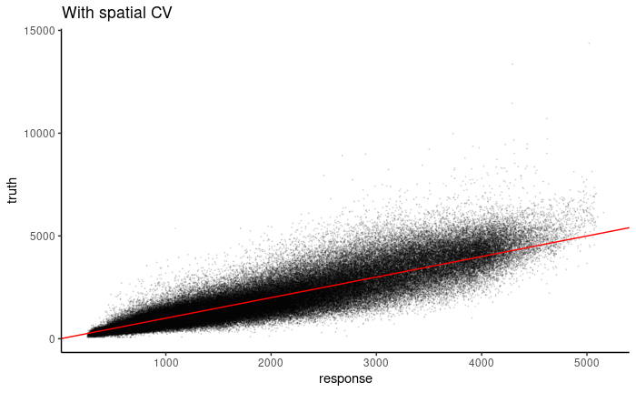

```r
# Plot predicted vs true values

rf_predictions_spt %>%
  ggplot(aes(x = response, y = truth)) +
  geom_point(size = 0.1, alpha = 0.1) +
  geom_abline(intercept = 0, slope = 1, colour = "red") +
  theme_classic() +
  labs(title = "With spatial CV")
```

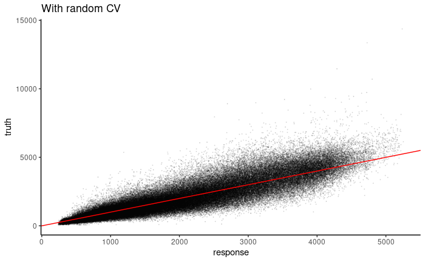

```r
rf_predictions_nspt %>%
  ggplot(aes(x = response, y = truth)) +
  geom_point(size = 0.1, alpha = 0.1) +
  geom_abline(intercept = 0, slope = 1, colour = "red") +
  theme_classic() +
  labs(title = "With random CV")
```

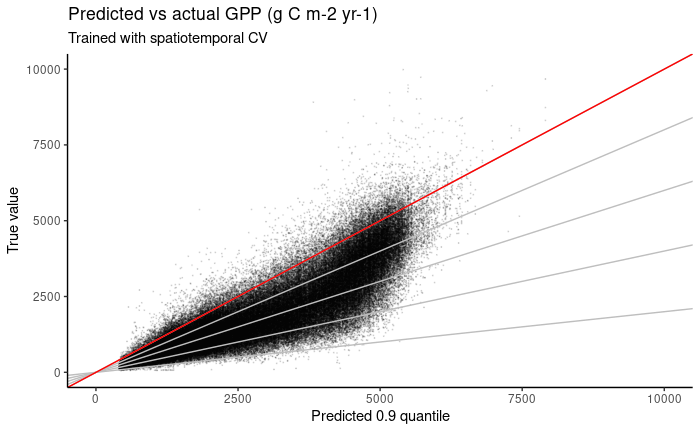

```r
# Predicted quantile values
rf_predictions_spt_qu <- predict(rf_tuned_spt$learner$model, task_gpp_spt$data(), type = "quantiles", quantiles = 0.9)
rf_predictions_nspt_qu <- predict(rf_tuned_nspt$learner$model, task_gpp_nspt$data(), type = "quantiles", quantiles = 0.9)

data_with_quantiles_spt <- task_gpp_spt$data() %>%
  bind_cols(rf_predictions_spt_qu$predictions) %>%
  rename(quantile_pred = "quantile= 0.9")
data_with_quantiles_nspt <- task_gpp_nspt$data() %>%
  bind_cols(rf_predictions_nspt_qu$predictions) %>%
  rename(quantile_pred = "quantile= 0.9")

ggplot(data_with_quantiles_spt, aes(x = quantile_pred, y = GPP)) +
  geom_point(size = 0.1, alpha = 0.1) +
  geom_abline(slope = seq(0.2, 1, 0.2), intercept = 0, colour = "grey") +
  geom_abline(slope = 1, intercept = 0, colour = "red") +
  theme_classic() +
  xlim(0, 10000) +
  ylim(0, 10000) +
  labs(x = "Predicted 0.9 quantile",
       y = "True value",
       title = "Predicted vs actual GPP (g C m-2 yr-1)",
       subtitle = "Trained with spatiotemporal CV")
```

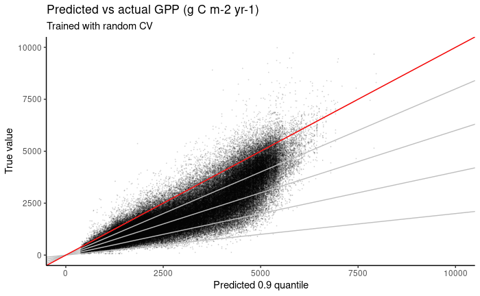

```r
ggplot(data_with_quantiles_nspt, aes(x = quantile_pred, y = GPP)) +
  geom_point(size = 0.1, alpha = 0.1) +
  geom_abline(slope = seq(0.2, 1, 0.2), intercept = 0, colour = "grey") +
  geom_abline(slope = 1, intercept = 0, colour = "red") +
  theme_classic() +
  xlim(0, 10000) +
  ylim(0, 10000) +
  labs(x = "Predicted 0.9 quantile",
       y = "True value",
       title = "Predicted vs actual GPP (g C m-2 yr-1)",
       subtitle = "Trained with random CV")
```

```r
NA
NA
```

It worked! I built two models that predict the 90th percentile with some degree of skill, and allow calculation of RPI.

Both models have similar performance, perhaps because I constrained them to retain a minimum of 200 points in each node to minimise overfitting. I need to check whether this works!

Add predictions to task data table and calculate RPI for the sample dataset using the model tuned with LLTO-CV.

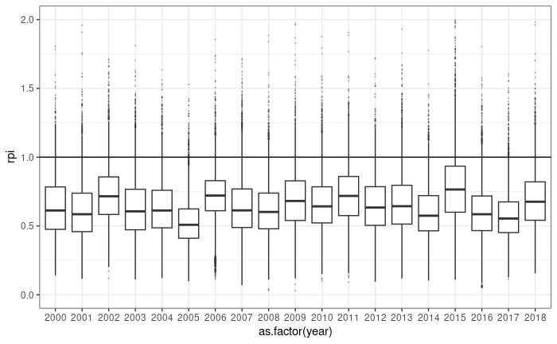

```r
sample_points_rpi <- data_with_quantiles_spt %>%
  mutate(rpi = GPP / quantile_pred) %>%
  bind_cols(sample_points_derived %>% select(id, year, geometry, precipitation))

ggplot(sample_points_rpi, aes(x = as.factor(year), y = rpi)) +
  geom_boxplot(outlier.size = 0.1, outlier.alpha = 0.3) +
  theme_bw() +
  geom_hline(yintercept = 1) +
  ylim(0, 2)
```

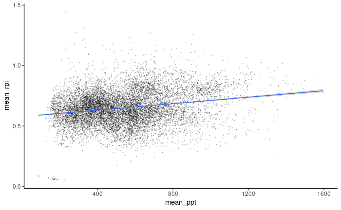

```r
sample_points_rpi %>%
  group_by(id) %>%
  summarise(mean_rpi = mean(rpi),
            mean_ppt = first(mean_ppt)) %>%
  ggplot(aes(x = mean_ppt, y = mean_rpi)) +
  geom_point(size = 0.2, alpha = 0.2) +
  geom_smooth(lwd = 0.5, method = "lm") +
  theme_classic()
```

```r
cor(sample_points_rpi$mean_ppt, sample_points_rpi$rpi)
```

```
[1] 0.1355418
```

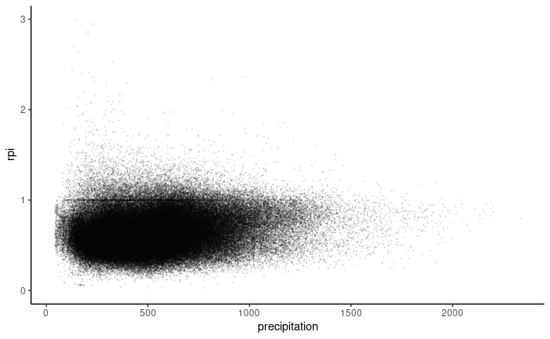

```r
ggplot(sample_points_rpi, aes(x = precipitation, y = rpi)) +
  geom_point(size = 0.1, alpha = 0.1) +
  theme_classic() +
  ylim(0, 3)
```

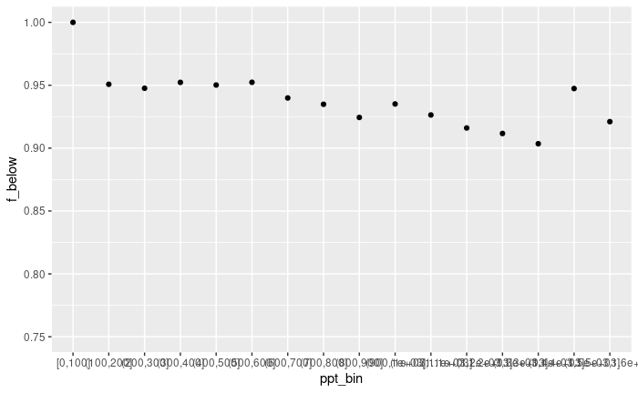

```r
sample_points_rpi %>%
  mutate(ppt_bin = cut_width(mean_ppt, width = 100, boundary = 0)) %>%
  group_by(ppt_bin) %>%
  summarise(bin_quantile = quantile(rpi, 0.9),
            f_above = sum(rpi > 1) / n(),
            f_below = sum(rpi < 1) / n(),
            mean_rpi = mean(rpi)) %>%
  ggplot(aes(x = ppt_bin, y = f_below)) +
  geom_point() +
  ylim(0.75, 1)
```

```
Deprecated tmap v3 code detected. Code translated to v4
```

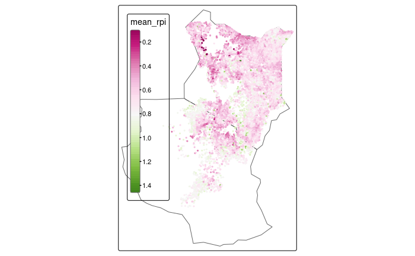

```r
# Test

# Plot mean RPI values spatially

sample_points_rpi_mean <- sample_points_rpi %>%
  group_by(id) %>%
  summarise(mean_rpi = mean(rpi),
            geometry = first(geometry)) %>%
  st_as_sf(crs = 4326)

library(tmap)

tm_shape(ke_tz) + tm_borders() +
  tm_shape(sample_points_rpi_mean) +
  tm_dots(col = "mean_rpi", palette = "PiYG", style = "cont", midpoint = 0.8)
```

Observations: - Some annual variations remain in the boxplots, which implies that we haven’t yet removed all impact of climate on the model. - There remains a weak positive correlation between mean_ppt and RPI, which may reflect the tighter grouping (fewer very low values) at high mean PPT. Perhaps this reflects greater resistance/less influence of dry years or land use at higher ppt? - There remains a line of points with fitted RPI exactly 1, but this is only ~1% of the dataset. I think it’s just a function of how RF models work. - Strangely there remains a slight bias in the quantile regression. Around 93% of sample points have an RPI < 1; if the regression were perfect, this should be almost exactly 90%. This applies across the whole range of precipitation values, too.

```r
pixel_ids_df <- sample_points_rpi %>%
  filter(wriTCFrac < 0.05) %>%
  select(id)

pixel_ids <- unique(pixel_ids_df$id)
set.seed(12)
random_ids <- sample(pixel_ids, 12)

rpi_sample <- sample_points_rpi %>%
  filter(id %in% random_ids)

ggplot(rpi_sample, aes(x = year, y = rpi)) +
  geom_line() +
  facet_wrap(~id, ncol = 3) +
  theme_bw()

# transparent <- theme(
#   panel.background = element_rect(fill='transparent'), #transparent panel bg
#   plot.background = element_rect(fill='transparent', color=NA), #transparent plot bg
#   panel.grid.major = element_blank(), #remove major gridlines
#   panel.grid.minor = element_blank(), #remove minor gridlines
#   legend.background = element_rect(fill='transparent'), #transparent legend bg
#   legend.box.background = element_rect(fill='transparent'), #transparent legend panel
#   axis.title = element_text(size = 20),
#   axis.text.x = element_text(size = 18),
#   axis.text.y = element_text(size = 0)
# )
#
# p1 <- ggplot(rpi_sample, aes(x = year, y = mean_ppt * ppt_anomaly)) +
#   geom_col(fill = "#203864", alpha = 0.75) +
#   theme_classic() +
#   labs(x = "Year", y = "Annual rainfall") +
#   transparent
#
# p2 <- ggplot(rpi_sample, aes(x = year, y = GPP)) +
#   geom_col(fill = "#4C5128", alpha = 0.75) +
#   theme_classic() +
#   labs(x = "Year", y = "Vegetation productivity") +
#   transparent
#
# p3 <- ggplot(rpi_sample, aes(x = year, y = rpi)) +
#   geom_col(fill = "#843C0C", alpha = 0.75) +
#   theme_classic() +
#   labs(x = "Year", y = "Vegetation condition") +
#   geom_hline(yintercept = 1, alpha = 0.75) +
#   transparent
#
# p1;p2;p3
#
# target <- random_ids[6]
#
# ggsave(here("results", "figures", "p1.png"), p1, bg = "transparent",
#        width = 16, height = 12, units = "cm")
```

[output not shown]

```
Deprecated tmap v3 code detected. Code translated to v4
Variable(s) "fill" contains positive and negative values, so midpoint is set to 0. Set midpoint = NA to show the full range of visual values.
```

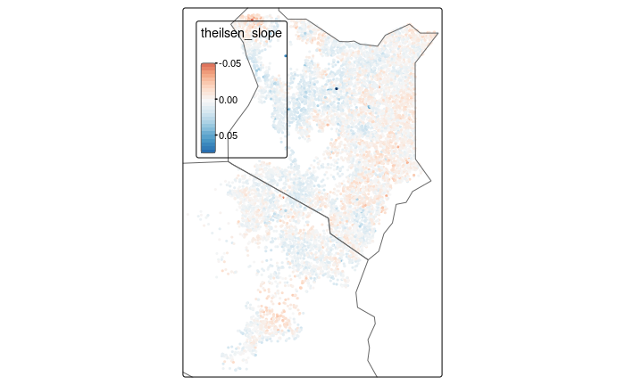

```r
tm_shape(rpi_trends_metrics %>% st_as_sf(crs = 4326)) + tm_dots(col = "theilsen_slope", palette = "RdBu", style = "cont") +
  tm_shape(ke_tz) + tm_borders()
```